# Stratified Random Sampling

Pietro Franceschi | pietro.franceschi@fmach.it

## Intro

During the presentation I claimed that, in presence of known subpopulations, **stratified random sampling** gives a more accurate estimate of the properties of the reference population. Let’s check this statement with a simulation …

## The question

Suppose that I’m interested in estimating the average height in a population of 10000 people, and that I know that 8000 of them are males and 2000 are females. To create my population I use the following properties:

- Males: mean = 180 cm, sd = 10 cm
- Females: mean = 150 cm, sd = 10 cm

## Running the simulations

First of all I create my population

```r
## the two subpopulations
males <- tibble(sex = "M", height = rnorm(8000, 180, 10))
females <- tibble(sex = "F", height = rnorm(2000, 150, 10))

## merge everything in a single tibble
mypop <- bind_rows(males, females)
```

Just for fun let’s give a look

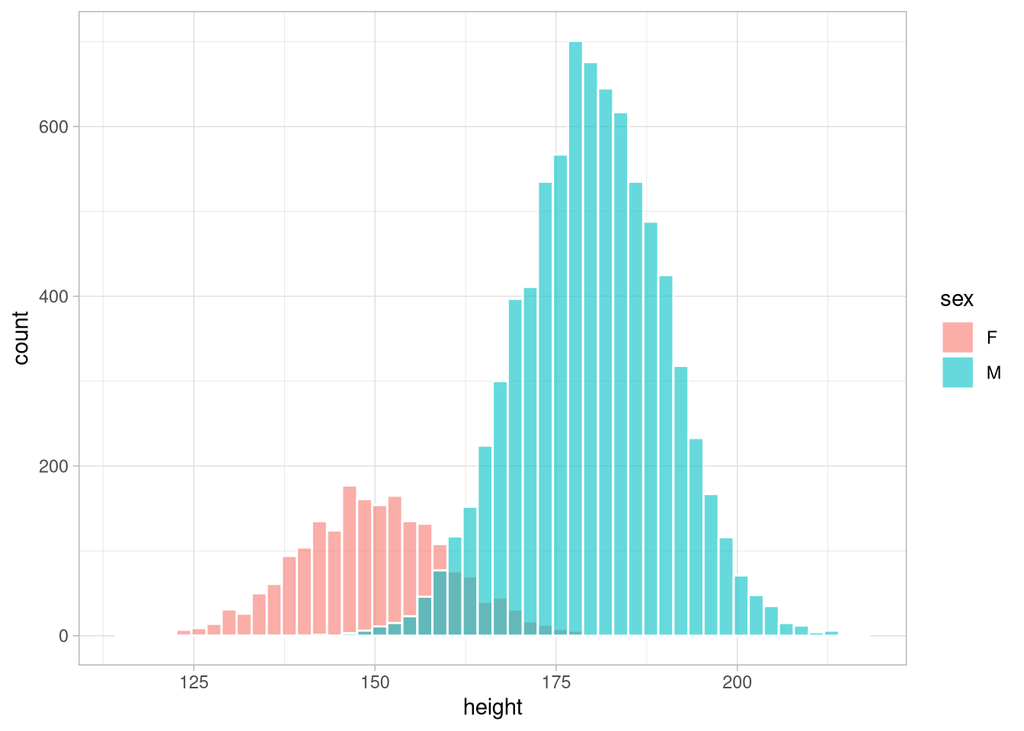

```r
mypop |>
  ggplot() +
  geom_histogram(aes(x = height, fill = sex), col = "white", alpha = 0.6, position = "identity", bins = 50) +
  theme_light()
```

Ok, we see what we expect: the two groups are different, and they are unbalanced.

## The problem

Suppose now that I’m interested in estimating the population mean. In my simulation this parameter is known …

```r
pop_mu <- mean(mypop$height)
pop_mu
```

```
## [1] 173.9763
```

In the plot it stays there …

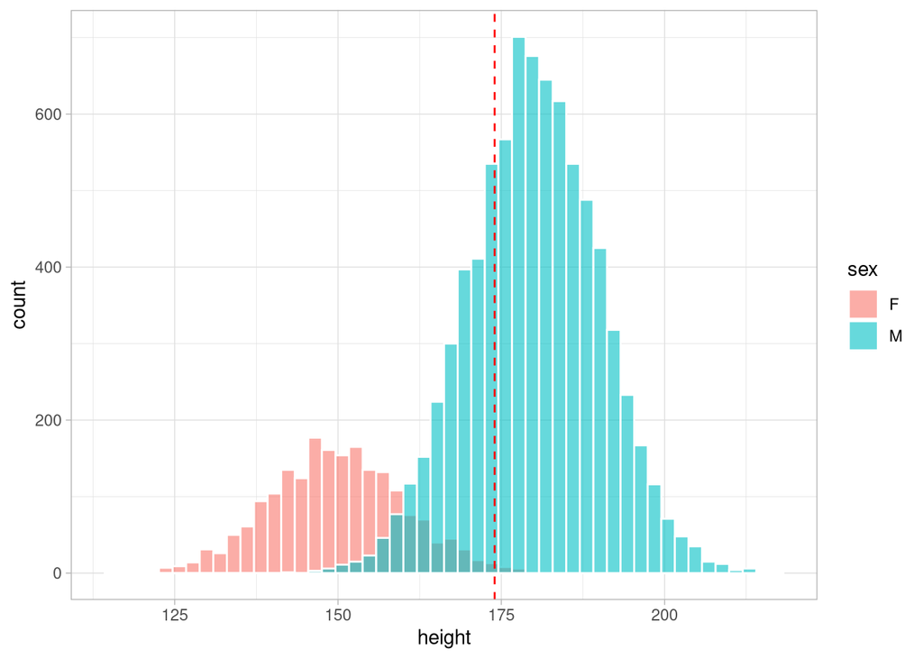

```r
mypop |>
  ggplot() +
  geom_histogram(aes(x = height, fill = sex), col = "white", alpha = 0.6, position = "identity", bins = 50) +
  geom_vline(xintercept = pop_mu, col = "red", lty = 2) +
  theme_light()
```

Suppose also that I do not have the money to measure the full population: the best I can do is to measure 30 people, and use their mean height to estimate the mean of the population.

What I can do in my simulation (and that I cannot do in real life) is to ask myself how **variable** my estimate of the population mean is, when I repeat the sampling several times.

## Simple Random Sampling

Suppose that I have no clue about the presence of the two subpopulations, so the best I can do to avoid biases is **simple random sampling**. Remember, *random* is my best way to avoid introducing biases.

So let’s simulate the extraction of 30 people from my population, and to see the variability of the process I do it 500 times

```r
## start creating the tibble container
x <- tibble(sampid = 1:500)

## here we do the simple random sampling ...
x <- x |>
  mutate(random_samples = map(sampid, \(i) sample(mypop$height, size = 30)))

## ... and we calculate the averages
x <- x |>
  mutate(random_averages = map_dbl(random_samples, mean))

head(x)
```

```
## # A tibble: 6 × 3
##   sampid random_samples random_averages
##    <int> <list>                   <dbl>
## 1      1 <dbl [30]>                175.
## 2      2 <dbl [30]>                176.
## 3      3 <dbl [30]>                173.
## 4      4 <dbl [30]>                174.
## 5      5 <dbl [30]>                173.
## 6      6 <dbl [30]>                174.
```

And we plot the estimates together with the true population mean

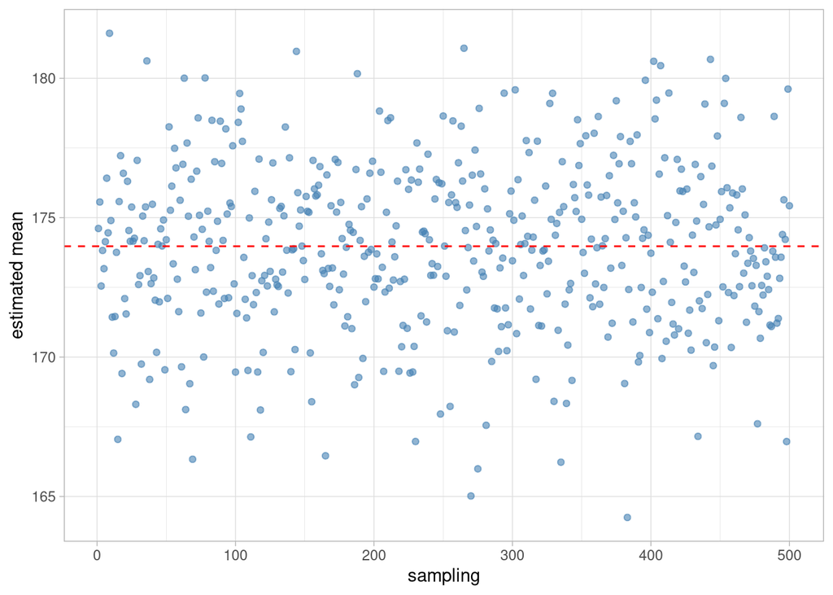

```r
x |>
  ggplot() +
  geom_point(aes(x = sampid, y = random_averages), col = "steelblue", alpha = 0.6) +
  geom_hline(yintercept = pop_mu, col = "red", lty = 2) +
  labs(x = "sampling", y = "estimated mean") +
  theme_light()
```

The same plot as a histogram …

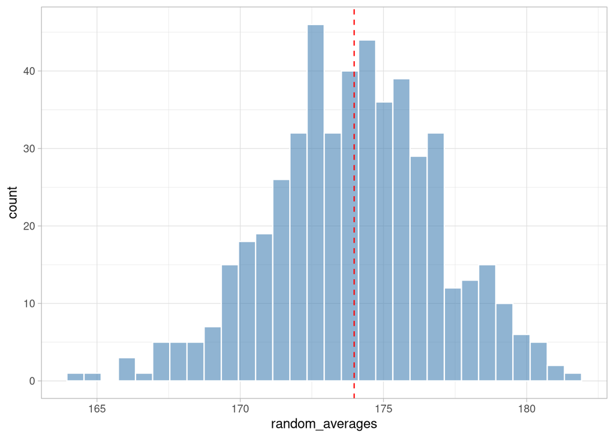

```r
x |>
  ggplot() +
  geom_histogram(aes(x = random_averages), fill = "steelblue", alpha = 0.6, col = "white", bins = 30) +
  geom_vline(xintercept = pop_mu, col = "red", lty = 2) +
  theme_light()
```

As we can see, the estimate has variability (:-P), it is centered around the correct value of the population mean, and it is normally distributed.

## Stratified sampling

Suppose now that I’m aware that my population is composed of different subgroups. To take this into account I switch to **stratified random sampling**.

If I stick to 30 people, I have to allocate them to the two groups in a proportion that mirrors the proportion of the individuals in the population

```r
nsamp <- 30

## the number of individuals to sample in each subpopulation
subfractions <- round(table(mypop$sex) / nrow(mypop) * nsamp)

subfractions
```

```
##
##  F  M
##  6 24
```

Let’s now code this new way of sampling

```r
## the heights of the two subpopulations
heights_m <- males$height
heights_f <- females$height

## here we do the random sampling inside each subpopulation
## and we return a vector with the samples extracted in a stratified way
x <- x |>
  mutate(stratified_random_samples = map(sampid, \(i) c(sample(heights_m, subfractions["M"]),
                                                        sample(heights_f, subfractions["F"]))))

## the average of the samples is again the estimate of the population mean
x <- x |>
  mutate(stratified_averages = map_dbl(stratified_random_samples, mean))

head(x)
```

```
## # A tibble: 6 × 5
##   sampid random_samples random_averages stratified_random_samples
##    <int> <list>                   <dbl> <list>
## 1      1 <dbl [30]>                175. <dbl [30]>
## 2      2 <dbl [30]>                176. <dbl [30]>
## 3      3 <dbl [30]>                173. <dbl [30]>
## 4      4 <dbl [30]>                174. <dbl [30]>
## 5      5 <dbl [30]>                173. <dbl [30]>
## 6      6 <dbl [30]>                174. <dbl [30]>
## # ℹ 1 more variable: stratified_averages <dbl>
```

And now we plot! To compare the two strategies it is convenient to put the estimates in a “long” format

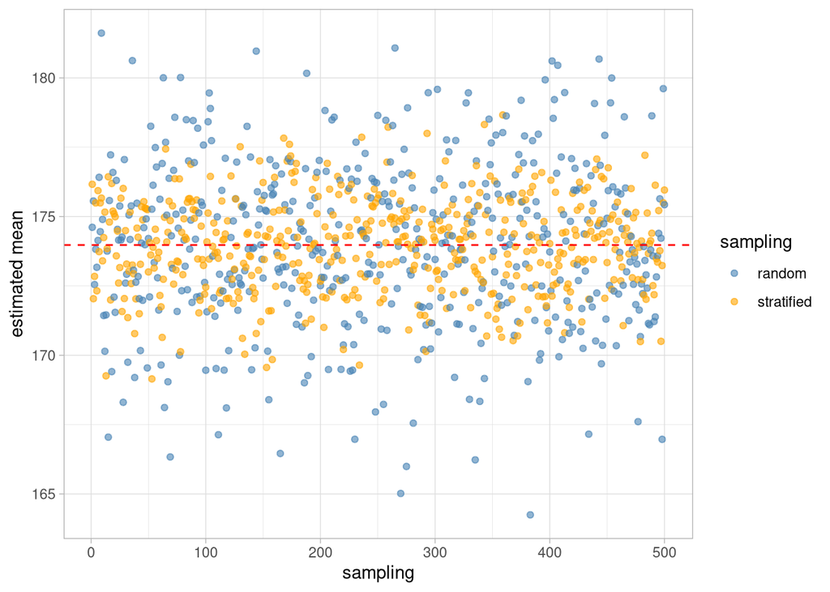

```r
x_long <- x |>
  select(sampid, random = random_averages, stratified = stratified_averages) |>
  pivot_longer(-sampid, names_to = "sampling", values_to = "estimate")

x_long |>
  ggplot() +
  geom_point(aes(x = sampid, y = estimate, col = sampling), alpha = 0.6) +
  geom_hline(yintercept = pop_mu, col = "red", lty = 2) +
  scale_color_manual(values = c(random = "steelblue", stratified = "orange")) +
  labs(x = "sampling", y = "estimated mean") +
  theme_light()
```

As before, in terms of a histogram

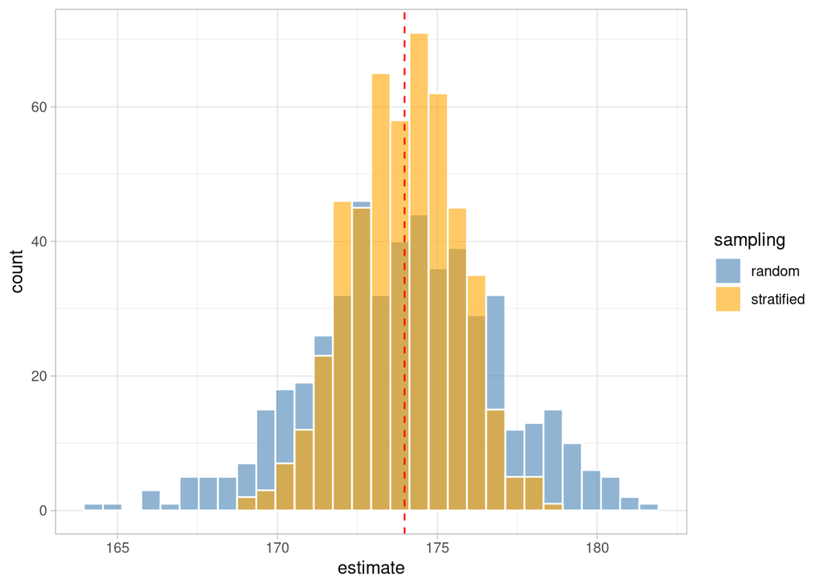

```r
x_long |>
  ggplot() +
  geom_histogram(aes(x = estimate, fill = sampling), alpha = 0.6, col = "white",
                 position = "identity", bins = 30) +
  geom_vline(xintercept = pop_mu, col = "red", lty = 2) +
  scale_fill_manual(values = c(random = "steelblue", stratified = "orange")) +
  theme_light()
```

As you can see the average is still good, but the *variability (variance) of my estimate is much smaller*. This is true for all the statistics you would like to estimate from your sample. If you think about it, the reason is that with stratification we ensure that our sample is representative of both subpopulations.

For our metabolomics business this is important when you are dealing with **observational studies**: in experiments, in general, you allocate the experimental units as you want.

**Something for you**

- Check what happens to the two types of sampling if you change the unbalance in the population
- Check what happens to the two types of sampling if you change the size of the sample (here 30)

Both tasks can be dealt with by changing my code above and looking at the results, or in a more “scientific” way by calculating the variability of the estimates for several settings, and showing the results in a plot.

## Effects of the sample size

Let’s organize everything in a table. The plan is

- one row for each sampling, with a column for the sample size
- two columns with the number of males and females to sample in the stratified case
- one column with the random sampling and one with the stratified sampling
- then the means
- then the summary of the SDs and a plot

```r
## the set of sizes we will consider
sizes <- c(30, 50, 100, 500)

m_fraction <- length(heights_m) / nrow(mypop)

sample_size_effect <- tibble(s_size = rep(sizes, each = 500)) |>
  mutate(n_m = round(m_fraction * s_size),
         n_f = s_size - n_m) |>
  mutate(random_samplings = map(s_size, \(n) sample(mypop$height, size = n)),
         stratified_samplings = map2(n_m, n_f, \(a, b) c(sample(heights_m, a), sample(heights_f, b)))) |>
  mutate(mean_random = map_dbl(random_samplings, mean),
         mean_strat = map_dbl(stratified_samplings, mean))
```

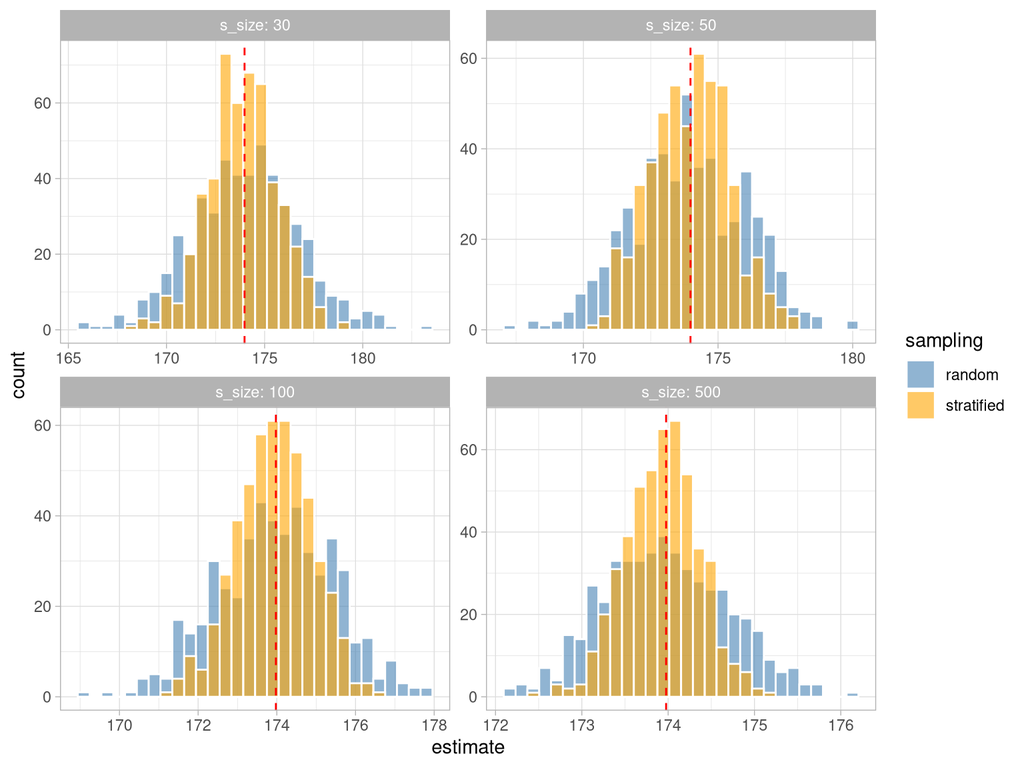

```r
sample_size_effect |>
  select(s_size, random = mean_random, stratified = mean_strat) |>
  pivot_longer(-s_size, names_to = "sampling", values_to = "estimate") |>
  ggplot() +
  geom_histogram(aes(x = estimate, fill = sampling), col = "white", alpha = 0.6,
                 position = "identity", bins = 30) +
  geom_vline(xintercept = pop_mu, lty = 2, col = "red") +
  scale_fill_manual(values = c(random = "steelblue", stratified = "orange")) +
  facet_wrap(~ s_size, scales = "free", labeller = label_both) +
  theme_light()
```

So in all cases stratifying is better …

```r
sample_size_effect |>
  group_by(s_size) |>
  summarize(sd_random = sd(mean_random),
            sd_strata = sd(mean_strat)) |>
  mutate(sd_ratio = sd_random / sd_strata)
```

```
## # A tibble: 4 × 4
##   s_size sd_random sd_strata sd_ratio
##    <dbl>     <dbl>     <dbl>    <dbl>
## 1     30     2.74      1.78      1.55
## 2     50     2.13      1.44      1.48
## 3    100     1.48      0.952     1.56
## 4    500     0.715     0.425     1.68
```

The SD of both estimates decreases with the sample size, but their ratio stays (roughly) constant: it is always advantageous to use stratified sampling.

- Our estimate of the “true” mean is less variable
- It is less likely to get an estimate completely off

Why is the ratio constant? With proportional allocation, stratified sampling removes the part of the variance due to the difference between the groups, leaving only the variance *within* the groups. Here the within-group SD is 10 cm, while the SD of the whole population is

```r
sd(mypop$height)
```

```
## [1] 15.65668
```

and the ratio between the two (1.57) is what we see in the table above, whatever the sample size.

**Can you now check the role of the unbalance in the populations?**